# Análisis de la intención de voto en Buenos Aires y Córdoba para las elecciones generales del año 2015

Al igual que con la base de Buenos Aires, cómo no es posible ponderar desde la propia función de kmeans, se replicarán las filas de la base en función de la ponderación. Además se crearon **variables dummy** con las ya mencionadas para poder realizar el análisis.

```r
df_cluster <- comp_elect_cba

# replicamos
df_cluster <- df_cluster[rep(seq_len(nrow(df_cluster)), df_cluster$ponderacion_eph), ]

# mostramos
df_cluster |>
  head() |>
  kable()
```

|  | ua | voto_oficialista | ponderacion_eph | gestion_cristina_x_aprueba | gestion_cristina_x_no_sabe | economia_fliar_2_anos_x_empeoro | economia_fliar_2_anos_x_se_mantuvo_igual | economia_fliar_2_anos_x_no_sabe | economia_pais_2_anos_x_empeoro | economia_pais_2_anos_x_se_mantuvo_igual | economia_pais_2_anos_x_no_sabe | continuidad_o_cambio_x_mantener_algunas_y_cambiar_otras | continuidad_o_cambio_x_cambiar_todas | continuidad_o_cambio_x_no_sabe |
| --- | --- | --- | --- | --- | --- | --- | --- | --- | --- | --- | --- | --- | --- | --- |
| 1 | 1 | 0 | 1.527288 | 0 | 0 | 1 | 0 | 0 | 0 | 1 | 0 | 0 | 1 | 0 |
| 3 | 3 | 0 | 1.035000 | 0 | 0 | 0 | 1 | 0 | 1 | 0 | 0 | 1 | 0 | 0 |
| 11 | 11 | 0 | 1.561429 | 0 | 0 | 1 | 0 | 0 | 1 | 0 | 0 | 1 | 0 | 0 |
| 12 | 12 | 0 | 1.209796 | 0 | 1 | 1 | 0 | 0 | 0 | 0 | 1 | 1 | 0 | 0 |
| 13 | 13 | 0 | 1.035000 | 0 | 0 | 0 | 1 | 0 | 1 | 0 | 0 | 0 | 1 | 0 |
| 14 | 14 | 0 | 1.058137 | 0 | 0 | 1 | 0 | 0 | 1 | 0 | 0 | 0 | 1 | 0 |

Al igual que con el df de Buenos Aires, vemos que al replicar con el ponderador hubo una disminución en la cantidad de registros

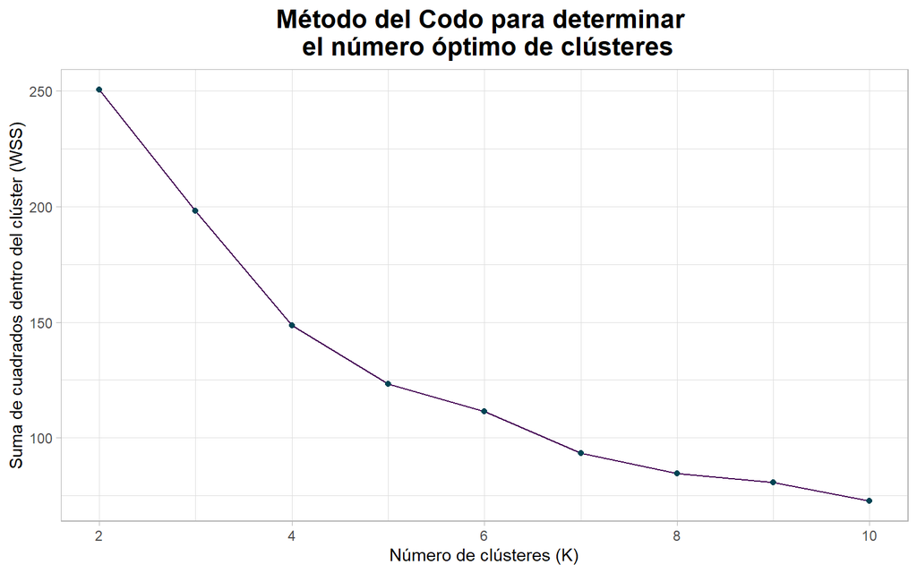

```r
df_cluster <- df_cluster |>
  dplyr::select(-ponderacion_eph, -ua)

# armamos el plot
k_values <- 2:10
wss <- numeric(length(k_values))

for (k in k_values) {
  km <- kmeans(df_cluster,centers = k, nstart = 10)
  wss[k-1] <- sum(km$withinss)
}

# Realizo el método de Elbow para saber cuantos clusters realizar
elbow_plot <- data.frame(K = k_values, WSS = wss) %>%
  ggplot(aes(x = K, y = WSS)) +
  geom_line(colour = "#440154") +
  geom_point(colour = "#014454") +
  labs(x = "Número de clústeres (K)", y = "Suma de cuadrados dentro del clúster (WSS)",
       title = "Método del Codo para determinar \n el número óptimo de clústeres") +
  theme_light() +
  theme(
    plot.title = element_text(size = 16L,
    face = "bold",
    hjust = 0.5),
    plot.subtitle = element_text(face = "italic",
    hjust = 0.5)
  )

elbow_plot
```

Vamos a realizar el análisis con 4 clusters

```r
# semilla
set.seed(123)

# realizamos el cluster
kmeans_result <- kmeans(df_cluster, centers = 4 )


# lo agregamos al dataset
df_cluster$cluster <- kmeans_result$cluster

# resumen
aggregate(. ~ cluster, data = df_cluster, FUN = mean) |>
  kable()
```

| cluster | voto_oficialista | gestion_cristina_x_aprueba | gestion_cristina_x_no_sabe | economia_fliar_2_anos_x_empeoro | economia_fliar_2_anos_x_se_mantuvo_igual | economia_fliar_2_anos_x_no_sabe | economia_pais_2_anos_x_empeoro | economia_pais_2_anos_x_se_mantuvo_igual | economia_pais_2_anos_x_no_sabe | continuidad_o_cambio_x_mantener_algunas_y_cambiar_otras | continuidad_o_cambio_x_cambiar_todas | continuidad_o_cambio_x_no_sabe |
| --- | --- | --- | --- | --- | --- | --- | --- | --- | --- | --- | --- | --- |
| 1 | 0.0000000 | 0.0000000 | 1.0000000 | 0.0714286 | 0.0000000 | 0.9285714 | 0.0000000 | 0.0000000 | 1 | 0.2142857 | 0.0000000 | 0.7857143 |
| 2 | 0.6666667 | 0.5454545 | 0.0606061 | 0.0303030 | 0.5454545 | 0.0909091 | 0.0000000 | 0.9696970 | 0 | 0.3939394 | 0.0606061 | 0.2727273 |
| 3 | 1.0000000 | 1.0000000 | 0.0000000 | 0.0000000 | 0.1000000 | 0.0333333 | 0.0000000 | 0.0000000 | 0 | 0.1666667 | 0.0000000 | 0.2000000 |
| 4 | 0.0190476 | 0.0476190 | 0.0095238 | 0.7333333 | 0.1523810 | 0.0095238 | 0.9238095 | 0.0380952 | 0 | 0.5333333 | 0.4190476 | 0.0285714 |

*Cluster 4*: **Los escepticos** En este grupo, el voto por el FPV es bajo, con un valor promedio de aproximadamente 0.02. La aprobación de la gestión de Cristina es baja, con solo el 4% que aprueba. La percepción de la economía familiar en los últimos dos años es mayoritariamente negativa, con un 73% que cree que empeoró. También consideran que la economía del país empeoró en un 92%. Tienen una preferencia por cambiar algunas políticas actuales y mantener otras.

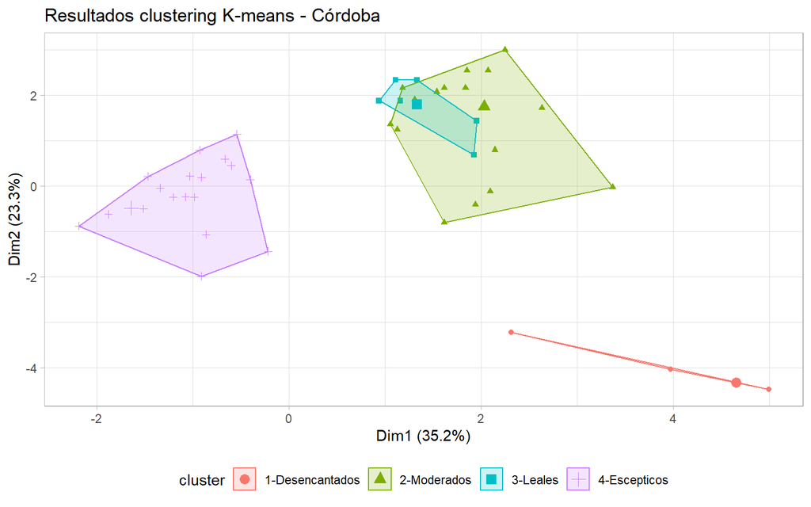

```r
# Le ponemos los nombres a los clusters
cluster_names <- c("1-Desencantados", "2-Moderados", "3-Leales", "4-Escepticos")

kmeans_result$cluster <- cluster_names[kmeans_result$cluster]

# Visualizamos
fviz_cluster(kmeans_result, data = df_cluster, geom = "point") +
  theme_light() +  theme(legend.position = "bottom") +
  labs(title = "Resultados clustering K-means - Córdoba")
```

### Conclusiones

Se puede afirmar entonces que en el caso de la Provincia de Buenos Aires y Córdoba *hay una relación entre la percepción de la situación económica y el voto o no por la continuidad del gobierno oficialista*. Es decir, quienes consideran que su situación económica empeoró en lineas generales eligen votar candidatos de otros frentes y prefieren cambios en las políticas públicas elaboradas. Por otro lado, a diferencia de Buenos Aires donde hay grupos más marcados que votarían y no votarían al FPV, en el caso de córdoba existe un cuarto grupo más moderado que muestra un voto relativamente alto por el FPV y una percepción mixta sobre la gestión de Cristina.

## Modelo sociológico

El **Modelo Sociológico** por otro lado se enfoca en cómo factores sociales y demográficos influyen en las decisiones de voto de los ciudadanos Esta teoría considera que los contextos sociales y las características de los votantes tienen un impacto significativo en sus preferencias políticas y en su comportamiento electoral. De esta manera, *el elector forma sus opiniones y opciones políticas en función de las posiciones y características de su grupo de pertenencia en la sociedad en general*

Para analizar la intención de voto en función de la teoría de comportamiento electoral sociológica se utilizarán las variables `edad`, `sexo`,`niv_educativo`. Se llevará a cabo una **regresión logística** con el objetivo de analizar la relación entre estas variables predictoras y la variable de resultado (`voto_oficialista`) y determinar si existe una asociación significativa entre ellas.

### **Buenos Aires**

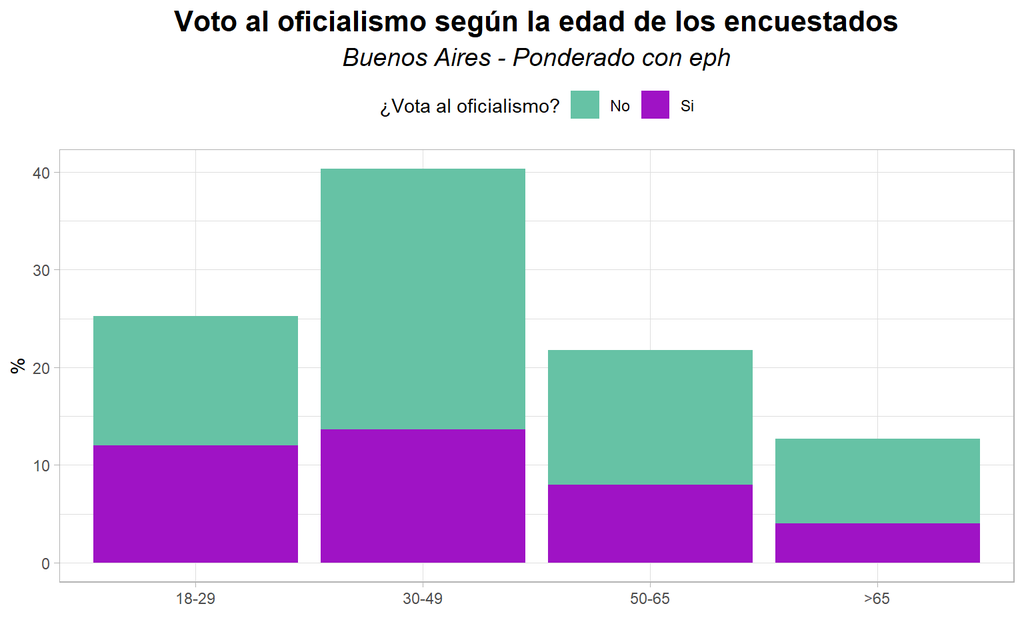

```r
#colnames(df_potencial_ba)
df_socio_pba <-  df_potencial_ba |>
  select(ua,edad,sexo,niv_educativo,ponderacion_eph, voto_acotado) |>
  mutate(voto_oficialista = ifelse(voto_acotado == "Daniel Scioli", "Si","No")) |>
  select(-voto_acotado)

rownames(df_socio_pba) <- df_socio_pba$ua

# Graficamos
df_socio_pba |>
  group_by(voto_oficialista, edad) |>
  summarise(total = sum(ponderacion_eph)) |>
  mutate(porcentaje = total/sum(df_socio_pba$ponderacion_eph),
         porcentaje = porcentaje*100)  %>%
 ggplot() +
 aes(x = edad, y = porcentaje, fill = voto_oficialista) +
 geom_col() +
 scale_fill_manual(values = c(No = "#66C2A5",
Si = "#9F13C5")) +
 labs(x = " ", y = "%", title = "Voto al oficialismo según la edad de los encuestados",
 subtitle = "Buenos Aires - Ponderado con eph", fill = "¿Vota al oficialismo?") +
 theme_light() +
 theme(legend.position = "top", plot.title = element_text(size = 16L, face = "bold", hjust = 0.5),
 plot.subtitle = element_text(size = 14L, face = "italic", hjust = 0.5))
```

Entre los que votan al oficialismo el rango etario se encuentra más distribuido entre los 18 y 65 años. Por el otro lado, los votantes de la oposición se concentran entre los 30-49 en mayor medida

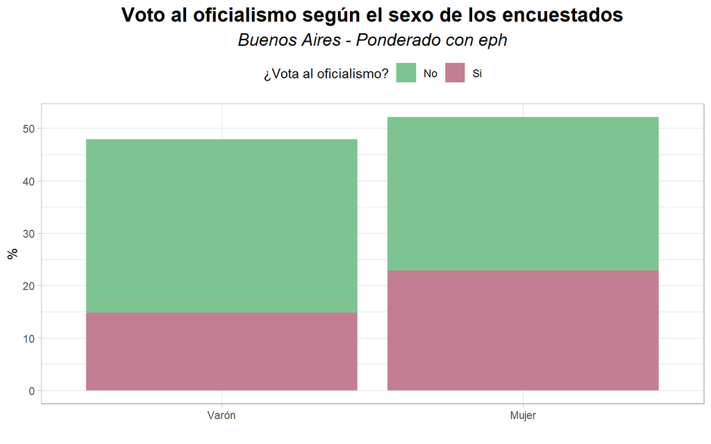

```r
df_socio_pba |>
  group_by(voto_oficialista, sexo) |>
  summarise(total = sum(ponderacion_eph)) |>
  mutate(porcentaje = total/sum(df_socio_pba$ponderacion_eph),
         porcentaje = porcentaje*100) %>%
 ggplot() +
 aes(x = sexo, y = porcentaje, fill = voto_oficialista) +
 geom_col() +
 scale_fill_manual(values = c(No = "#7ec492",
Si = "#c47e92")) +
 labs(x = " ", y = "%", title = "Voto al oficialismo según el sexo de los encuestados",
 subtitle = "Buenos Aires - Ponderado con eph", fill = "¿Vota al oficialismo?") +
 theme_light() +
 theme(legend.position = "top", plot.title = element_text(size = 16L, face = "bold", hjust = 0.5),
 plot.subtitle = element_text(size = 14L, face = "italic", hjust = 0.5))
```

Entre los votantes del FDT hay mayor proporción de mujeres. En cambio en el voto no oficialista la distribución se encuentra más pareja

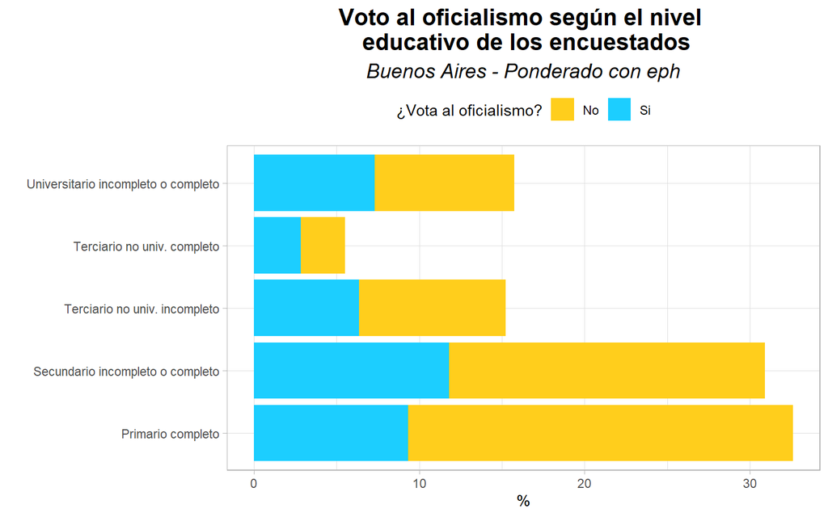

```r
df_socio_pba |>
  group_by(voto_oficialista, niv_educativo) |>
  summarise(total = sum(ponderacion_eph)) |>
  mutate(porcentaje = total/sum(df_socio_pba$ponderacion_eph),
         porcentaje = porcentaje*100) %>%
 ggplot() +
 aes(x = niv_educativo, y = porcentaje, fill = voto_oficialista) +
 geom_col() +
 scale_fill_manual(values = c(No = "#ffce1c",
Si = "#1cceff")) +
 labs(x = " ", y = "%", title = "Voto al oficialismo según el nivel \n educativo de los encuestados",
 subtitle = "Buenos Aires - Ponderado con eph", fill = "¿Vota al oficialismo?") +
 theme_light() +
 theme(legend.position = "top", plot.title = element_text(size = 16L, face = "bold", hjust = 0.5),
 plot.subtitle = element_text(size = 14L, face = "italic", hjust = 0.5)) +
  coord_flip()
```

El voto no oficialista se concentra mayormente entre quienes tienen primario completo y secundario. Y, el voto oficialista entre quienes tienen secundario, primario y terciario.

Realizamos la **regresión logística** para analizar la relación entre las variables y el voto al oficialismo

```r
# Creo variables dummys

# armo df para crear dummys
df_dummys <- df_socio_pba |> dplyr::select(-ponderacion_eph, -ua, -voto_oficialista,-sexo)

#Creating Dummy Variables
dummy<- data.frame(sapply(df_dummys,function(x) data.frame(model.matrix(~x-1,data =df_dummys))[,-1])) |>
  clean_names()

# uno dfs
df_logit_ba <- df_socio_pba|>
  dplyr::select(ponderacion_eph, sexo, voto_oficialista)|>
  mutate(sexo = ifelse(sexo == "Mujer", 1, 0),
         voto_oficialista = ifelse(voto_oficialista == "Si", 1, 0)) |>
   cbind(dummy)

#colnames(df_logit_ba)

# Modelo con todas las variables
modelo <- glm(voto_oficialista ~ edad_x30_49 + edad_x50_65 + edad_x_65 +sexo + niv_educativo_x_secundario_incompleto_o_completo + niv_educativo_x_terciario_no_univ_incompleto + niv_educativo_x_terciario_no_univ_completo + niv_educativo_x_universitario_incompleto_o_completo + voto_oficialista , data = df_logit_ba, family = binomial, weights = ponderacion_eph)

summary(modelo)
```

```
##
## Call:
## glm(formula = voto_oficialista ~ edad_x30_49 + edad_x50_65 +
##     edad_x_65 + sexo + niv_educativo_x_secundario_incompleto_o_completo +
##     niv_educativo_x_terciario_no_univ_incompleto + niv_educativo_x_terciario_no_univ_completo +
##     niv_educativo_x_universitario_incompleto_o_completo + voto_oficialista,
##     family = binomial, data = df_logit_ba, weights = ponderacion_eph)
##
## Coefficients:
##                                                     Estimate Std. Error z value
## (Intercept)                                          -0.6796     0.3149  -2.158
## edad_x30_49                                          -0.5910     0.2769  -2.135
## edad_x50_65                                          -0.2955     0.3325  -0.889
## edad_x_65                                            -0.5365     0.4055  -1.323
## sexo                                                  0.4162     0.2327   1.788
## niv_educativo_x_secundario_incompleto_o_completo      0.2870     0.3065   0.936
## niv_educativo_x_terciario_no_univ_incompleto          0.4330     0.3713   1.166
## niv_educativo_x_terciario_no_univ_completo            0.9043     0.5057   1.788
## niv_educativo_x_universitario_incompleto_o_completo   0.6501     0.3720   1.748
##                                                     Pr(>|z|)
## (Intercept)                                           0.0309 *
## edad_x30_49                                           0.0328 *
## edad_x50_65                                           0.3742
## edad_x_65                                             0.1859
## sexo                                                  0.0737 .
## niv_educativo_x_secundario_incompleto_o_completo      0.3490
## niv_educativo_x_terciario_no_univ_incompleto          0.2435
## niv_educativo_x_terciario_no_univ_completo            0.0737 .
## niv_educativo_x_universitario_incompleto_o_completo   0.0805 .
## ---
## Signif. codes:  0 '***' 0.001 '**' 0.01 '*' 0.05 '.' 0.1 ' ' 1
##
## (Dispersion parameter for binomial family taken to be 1)
##
##     Null deviance: 494.18  on 372  degrees of freedom
## Residual deviance: 477.14  on 364  degrees of freedom
## AIC: 453.67
##
## Number of Fisher Scoring iterations: 4
```

A continuación, se utilizará el método STEPAIC que permite realizar el proceso de selección de variables mediante el Akaike (AIC). El AIC es una métrica que se utiliza para ocmparar diferentes modelos y seleccionar el mejor ajustado para los datos

```r
#Usamos stepAIC para generar el mejor modelo
final_model <- MASS::stepAIC(modelo)
```

```
## Start:  AIC=453.67
## voto_oficialista ~ edad_x30_49 + edad_x50_65 + edad_x_65 + sexo +
##     niv_educativo_x_secundario_incompleto_o_completo + niv_educativo_x_terciario_no_univ_incompleto +
##     niv_educativo_x_terciario_no_univ_completo + niv_educativo_x_universitario_incompleto_o_completo +
##     voto_oficialista
##
##
## Step:  AIC=453.67
## voto_oficialista ~ edad_x30_49 + edad_x50_65 + edad_x_65 + sexo +
##     niv_educativo_x_secundario_incompleto_o_completo + niv_educativo_x_terciario_no_univ_incompleto +
##     niv_educativo_x_terciario_no_univ_completo + niv_educativo_x_universitario_incompleto_o_completo
##
##                                                       Df Deviance    AIC
## - edad_x50_65                                          1   477.93 452.46
## - niv_educativo_x_secundario_incompleto_o_completo     1   478.01 452.55
## - niv_educativo_x_terciario_no_univ_incompleto         1   478.49 453.02
## - edad_x_65                                            1   478.92 453.45
## <none>                                                     477.14 453.67
## - niv_educativo_x_universitario_incompleto_o_completo  1   480.19 454.72
## - niv_educativo_x_terciario_no_univ_completo           1   480.31 454.85
## - sexo                                                 1   480.35 454.89
## - edad_x30_49                                          1   481.71 456.25
##
## Step:  AIC=451.27
## voto_oficialista ~ edad_x30_49 + edad_x_65 + sexo + niv_educativo_x_secundario_incompleto_o_completo +
##     niv_educativo_x_terciario_no_univ_incompleto + niv_educativo_x_terciario_no_univ_completo +
##     niv_educativo_x_universitario_incompleto_o_completo
##
##                                                       Df Deviance    AIC
## - edad_x_65                                            1   479.02 450.36
## - niv_educativo_x_secundario_incompleto_o_completo     1   479.52 450.86
## <none>                                                     477.93 451.27
## - niv_educativo_x_terciario_no_univ_incompleto         1   479.97 451.31
## - sexo                                                 1   480.94 452.28
## - niv_educativo_x_terciario_no_univ_completo           1   481.45 452.79
## - edad_x30_49                                          1   481.76 453.09
## - niv_educativo_x_universitario_incompleto_o_completo  1   482.08 453.42
##
## Step:  AIC=449.24
## voto_oficialista ~ edad_x30_49 + sexo + niv_educativo_x_secundario_incompleto_o_completo +
##     niv_educativo_x_terciario_no_univ_incompleto + niv_educativo_x_terciario_no_univ_completo +
##     niv_educativo_x_universitario_incompleto_o_completo
##
##                                                       Df Deviance    AIC
## <none>                                                     479.02 449.24
## - niv_educativo_x_secundario_incompleto_o_completo     1   481.28 449.49
## - sexo                                                 1   481.60 449.81
## - niv_educativo_x_terciario_no_univ_incompleto         1   481.78 450.00
## - edad_x30_49                                          1   482.11 450.33
## - niv_educativo_x_terciario_no_univ_completo           1   482.88 451.09
## - niv_educativo_x_universitario_incompleto_o_completo  1   484.29 452.51
```

```r
 # mostramos
summary(final_model)
```

```
##
## Call:
## glm(formula = voto_oficialista ~ edad_x30_49 + sexo + niv_educativo_x_secundario_incompleto_o_completo +
##     niv_educativo_x_terciario_no_univ_incompleto + niv_educativo_x_terciario_no_univ_completo +
##     niv_educativo_x_universitario_incompleto_o_completo, family = binomial,
##     data = df_logit_ba, weights = ponderacion_eph)
##
## Coefficients:
##                                                     Estimate Std. Error z value
## (Intercept)                                          -0.9545     0.2291  -4.167
## edad_x30_49                                          -0.4115     0.2356  -1.746
## sexo                                                  0.3655     0.2280   1.603
## niv_educativo_x_secundario_incompleto_o_completo      0.4292     0.2865   1.498
## niv_educativo_x_terciario_no_univ_incompleto          0.5862     0.3518   1.666
## niv_educativo_x_terciario_no_univ_completo            0.9885     0.5016   1.971
## niv_educativo_x_universitario_incompleto_o_completo   0.8087     0.3526   2.293
##                                                     Pr(>|z|)
## (Intercept)                                         3.09e-05 ***
## edad_x30_49                                           0.0808 .
## sexo                                                  0.1089
## niv_educativo_x_secundario_incompleto_o_completo      0.1341
## niv_educativo_x_terciario_no_univ_incompleto          0.0956 .
## niv_educativo_x_terciario_no_univ_completo            0.0487 *
## niv_educativo_x_universitario_incompleto_o_completo   0.0218 *
## ---
## Signif. codes:  0 '***' 0.001 '**' 0.01 '*' 0.05 '.' 0.1 ' ' 1
##
## (Dispersion parameter for binomial family taken to be 1)
##
##     Null deviance: 494.18  on 372  degrees of freedom
## Residual deviance: 479.02  on 366  degrees of freedom
## AIC: 449.24
##
## Number of Fisher Scoring iterations: 4
```

Para este modelo la variable nivel educativo (universitario y terciario) es la que más podría predecir el voto al oficialismo junto con el rango de edad de 30-49 (a la inversa). Es decir, quienes se encuentran en ese rango de edad tienen menos probabilidad de votar al FPV

### **Córdoba**

Repetimos el procedimiento para la base de **Córdoba**

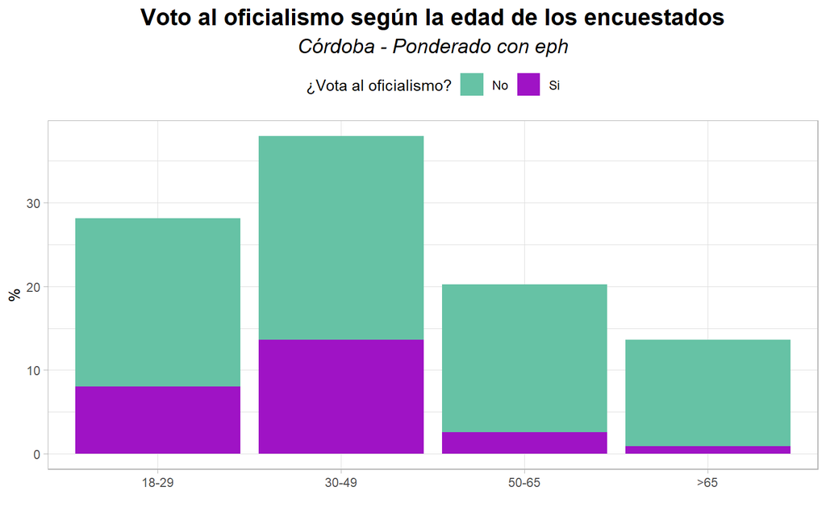

```r
#colnames(df_potencial_cba)
df_socio_cba <-  df_potencial_cba |>
  select(ua,edad,sexo,niv_educativo,ponderacion_eph, voto_acotado) |>
  mutate(voto_oficialista = ifelse(voto_acotado == "Daniel Scioli", "Si","No")) |>
  select(-voto_acotado)


rownames(df_socio_cba) <- df_socio_cba$ua

df_socio_cba |>
  group_by(voto_oficialista, edad) |>
  summarise(total = sum(ponderacion_eph)) |>
  mutate(porcentaje = total/sum(df_socio_cba$ponderacion_eph),
         porcentaje = porcentaje*100)  %>%
 ggplot() +
 aes(x = edad, y = porcentaje, fill = voto_oficialista) +
 geom_col() +
 scale_fill_manual(values = c(No = "#66C2A5",
Si = "#9F13C5")) +
 labs(x = " ", y = "%", title = "Voto al oficialismo según la edad de los encuestados",
 subtitle = "Córdoba - Ponderado con eph", fill = "¿Vota al oficialismo?") +
 theme_light() +
 theme(legend.position = "top", plot.title = element_text(size = 16L, face = "bold", hjust = 0.5),
 plot.subtitle = element_text(size = 14L, face = "italic", hjust = 0.5))
```

Entre los que votan al oficialismo el rango etario con mayor proporción es el de 30-49 años. Por el otro lado, los votantes de la oposición se concentran entre los 18-65 en mayor medida

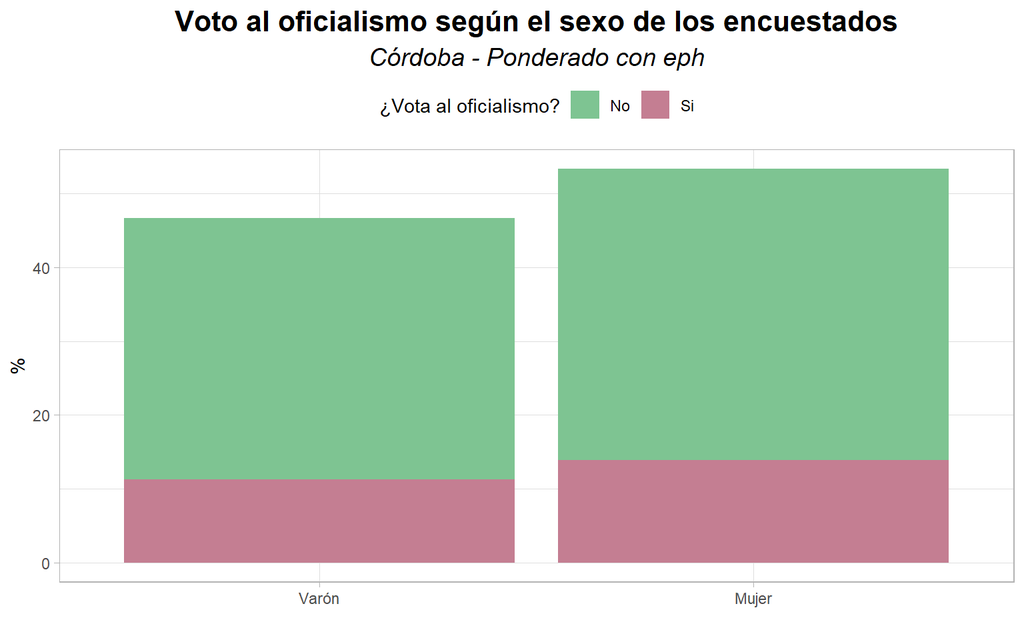

```r
df_socio_cba |>
  group_by(voto_oficialista, sexo) |>
  summarise(total = sum(ponderacion_eph)) |>
  mutate(porcentaje = total/sum(df_socio_cba$ponderacion_eph),
         porcentaje = porcentaje*100) %>%
 ggplot() +
 aes(x = sexo, y = porcentaje, fill = voto_oficialista) +
 geom_col() +
 scale_fill_manual(values = c(No = "#7ec492",
Si = "#c47e92")) +
 labs(x = " ", y = "%", title = "Voto al oficialismo según el sexo de los encuestados",
 subtitle = "Córdoba - Ponderado con eph", fill = "¿Vota al oficialismo?") +
 theme_light() +
 theme(legend.position = "top", plot.title = element_text(size = 16L, face = "bold", hjust = 0.5),
 plot.subtitle = element_text(size = 14L, face = "italic", hjust = 0.5))
```

En ambos tipos de votantes (oficialistas y no oficialistas) hay una distribución bastante pareja entre los géneros

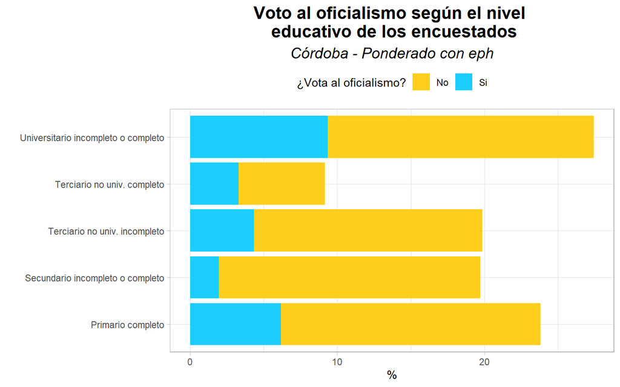

```r
df_socio_cba |>
  group_by(voto_oficialista, niv_educativo) |>
  summarise(total = sum(ponderacion_eph)) |>
  mutate(porcentaje = total/sum(df_socio_cba$ponderacion_eph),
         porcentaje = porcentaje*100) |>
  select(-total)%>%
 ggplot() +
 aes(x = niv_educativo, y = porcentaje, fill = voto_oficialista) +
 geom_col() +
 scale_fill_manual(values = c(No = "#ffce1c",
Si = "#1cceff")) +
 labs(x = " ", y = "%", title = "Voto al oficialismo según el nivel \n educativo de los encuestados",
 subtitle = "Córdoba - Ponderado con eph", fill = "¿Vota al oficialismo?") +
 theme_light() +
 theme(legend.position = "top", plot.title = element_text(size = 16L, face = "bold", hjust = 0.5),
 plot.subtitle = element_text(size = 14L, face = "italic", hjust = 0.5)) +
  coord_flip()
```

Realizamos la **regresión logística** para analizar la relación entre las variables

```r
# Creo variables dummys
# armo df para crear dummys
df_dummys <- df_socio_cba |> dplyr::select(-ponderacion_eph, -ua, -voto_oficialista,-sexo)

# creo dummys
dummy<- data.frame(sapply(df_dummys,function(x) data.frame(model.matrix(~x-1,data =df_dummys))[,-1])) |>
  clean_names()

# uno dfs
df_logit_cba <- df_socio_cba|>
  dplyr::select(ponderacion_eph, sexo, voto_oficialista)|>
  mutate(sexo = ifelse(sexo == "Mujer", 1, 0),
         voto_oficialista = ifelse(voto_oficialista == "Si", 1, 0)) |>
   cbind(dummy)

#colnames(df_logit_ba)


# Modelo con todas las variables
modelo <- glm(voto_oficialista ~ edad_x30_49 + edad_x50_65 + edad_x_65 +sexo + niv_educativo_x_secundario_incompleto_o_completo + niv_educativo_x_terciario_no_univ_incompleto + niv_educativo_x_terciario_no_univ_completo + niv_educativo_x_universitario_incompleto_o_completo + voto_oficialista , data = df_logit_cba, family = binomial, weights = ponderacion_eph)

summary(modelo)
```

```
##
## Call:
## glm(formula = voto_oficialista ~ edad_x30_49 + edad_x50_65 +
##     edad_x_65 + sexo + niv_educativo_x_secundario_incompleto_o_completo +
##     niv_educativo_x_terciario_no_univ_incompleto + niv_educativo_x_terciario_no_univ_completo +
##     niv_educativo_x_universitario_incompleto_o_completo + voto_oficialista,
##     family = binomial, data = df_logit_cba, weights = ponderacion_eph)
##
## Coefficients:
##                                                      Estimate Std. Error
## (Intercept)                                         -0.647359   0.312113
## edad_x30_49                                          0.366038   0.350193
## edad_x50_65                                         -0.827042   0.457562
## edad_x_65                                           -1.799367   0.652313
## sexo                                                 0.063499   0.291093
## niv_educativo_x_secundario_incompleto_o_completo    -1.380655   0.532217
## niv_educativo_x_terciario_no_univ_incompleto        -0.681470   0.444911
## niv_educativo_x_terciario_no_univ_completo          -0.021171   0.529485
## niv_educativo_x_universitario_incompleto_o_completo -0.003058   0.394030
##                                                     z value Pr(>|z|)
## (Intercept)                                          -2.074  0.03807 *
## edad_x30_49                                           1.045  0.29591
## edad_x50_65                                          -1.807  0.07068 .
## edad_x_65                                            -2.758  0.00581 **
## sexo                                                  0.218  0.82732
## niv_educativo_x_secundario_incompleto_o_completo     -2.594  0.00948 **
## niv_educativo_x_terciario_no_univ_incompleto         -1.532  0.12560
## niv_educativo_x_terciario_no_univ_completo           -0.040  0.96811
## niv_educativo_x_universitario_incompleto_o_completo  -0.008  0.99381
## ---
## Signif. codes:  0 '***' 0.001 '**' 0.01 '*' 0.05 '.' 0.1 ' ' 1
##
## (Dispersion parameter for binomial family taken to be 1)
##
##     Null deviance: 361.04  on 319  degrees of freedom
## Residual deviance: 324.94  on 311  degrees of freedom
## AIC: 333.3
##
## Number of Fisher Scoring iterations: 5
```

Utilizando todas las variables sociodemográficas, a diferencia del análisis en **Buenos Aires** se observa que, en este primer modelo, el *sexo* no es estadísticamente significativo para predecir el voto al oficialismo. El `niv_educativo_x_secundario_incompleto_o_completo`, por otro lado con un p-value de 0.00948 indica que manteniendo constantes las demás variables en el modelo, las personas con secundario tienen menos probabilidades de votar por el oficialismo en comparación con el resto. De la misma manera ocurre con `edad_x_65` y `edad_x50_65` .

A continuación se utilizará el método STEPAIC que permite realizar el proceso de selección de variables mediante el Akaike (AIC).

```r
#Usamos stepAIC para generar el mejor modelo
final_model <- MASS::stepAIC(modelo)
```

```
## Start:  AIC=333.3
## voto_oficialista ~ edad_x30_49 + edad_x50_65 + edad_x_65 + sexo +
##     niv_educativo_x_secundario_incompleto_o_completo + niv_educativo_x_terciario_no_univ_incompleto +
##     niv_educativo_x_terciario_no_univ_completo + niv_educativo_x_universitario_incompleto_o_completo +
##     voto_oficialista
##
##
## Step:  AIC=333.3
## voto_oficialista ~ edad_x30_49 + edad_x50_65 + edad_x_65 + sexo +
##     niv_educativo_x_secundario_incompleto_o_completo + niv_educativo_x_terciario_no_univ_incompleto +
##     niv_educativo_x_terciario_no_univ_completo + niv_educativo_x_universitario_incompleto_o_completo
##
##                                                       Df Deviance    AIC
## - niv_educativo_x_universitario_incompleto_o_completo  1   324.94 331.30
## - niv_educativo_x_terciario_no_univ_completo           1   324.94 331.30
## - sexo                                                 1   324.98 331.34
## - edad_x30_49                                          1   326.04 332.40
## <none>                                                     324.94 333.30
## - niv_educativo_x_terciario_no_univ_incompleto         1   327.33 333.69
## - edad_x50_65                                          1   328.42 334.78
## - niv_educativo_x_secundario_incompleto_o_completo     1   332.45 338.81
## - edad_x_65                                            1   335.46 341.82
##
## Step:  AIC=331.3
## voto_oficialista ~ edad_x30_49 + edad_x50_65 + edad_x_65 + sexo +
##     niv_educativo_x_secundario_incompleto_o_completo + niv_educativo_x_terciario_no_univ_incompleto +
##     niv_educativo_x_terciario_no_univ_completo
##
##                                                    Df Deviance    AIC
## - niv_educativo_x_terciario_no_univ_completo        1   324.94 329.30
## - sexo                                              1   324.98 329.35
## - edad_x30_49                                       1   326.18 330.55
## <none>                                                  324.94 331.30
## - edad_x50_65                                       1   328.54 332.91
## - niv_educativo_x_terciario_no_univ_incompleto      1   328.63 333.00
## - niv_educativo_x_secundario_incompleto_o_completo  1   335.49 339.86
## - edad_x_65                                         1   335.50 339.87
##
## Step:  AIC=329.33
## voto_oficialista ~ edad_x30_49 + edad_x50_65 + edad_x_65 + sexo +
```

[output cut: 18 more lines]

```
## - edad_x50_65                                       1   328.59 328.88
## - niv_educativo_x_terciario_no_univ_incompleto      1   328.84 329.13
## - edad_x_65                                         1   335.51 335.80
## - niv_educativo_x_secundario_incompleto_o_completo  1   335.98 336.26
##
## Step:  AIC=326.8
## voto_oficialista ~ edad_x50_65 + edad_x_65 + niv_educativo_x_secundario_incompleto_o_completo +
##     niv_educativo_x_terciario_no_univ_incompleto
##
##                                                    Df Deviance    AIC
## <none>                                                  326.55 326.80
## - niv_educativo_x_terciario_no_univ_incompleto      1   330.07 328.32
## - edad_x50_65                                       1   334.18 332.44
## - niv_educativo_x_secundario_incompleto_o_completo  1   337.46 335.71
## - edad_x_65                                         1   342.97 341.23
```

```r
# mostramos
summary(final_model)
```

```
##
## Call:
## glm(formula = voto_oficialista ~ edad_x50_65 + edad_x_65 + niv_educativo_x_secundario_incompleto_o_completo +
##     niv_educativo_x_terciario_no_univ_incompleto, family = binomial,
##     data = df_logit_cba, weights = ponderacion_eph)
##
## Coefficients:
##                                                  Estimate Std. Error z value
## (Intercept)                                       -0.4130     0.1743  -2.369
## edad_x50_65                                       -1.0448     0.4080  -2.561
## edad_x_65                                         -2.0138     0.6254  -3.220
## niv_educativo_x_secundario_incompleto_o_completo  -1.3565     0.4587  -2.958
## niv_educativo_x_terciario_no_univ_incompleto      -0.6365     0.3493  -1.822
##                                                  Pr(>|z|)
## (Intercept)                                       0.01784 *
## edad_x50_65                                       0.01044 *
## edad_x_65                                         0.00128 **
## niv_educativo_x_secundario_incompleto_o_completo  0.00310 **
## niv_educativo_x_terciario_no_univ_incompleto      0.06844 .
## ---
## Signif. codes:  0 '***' 0.001 '**' 0.01 '*' 0.05 '.' 0.1 ' ' 1
##
## (Dispersion parameter for binomial family taken to be 1)
##
##     Null deviance: 361.04  on 319  degrees of freedom
## Residual deviance: 326.55  on 315  degrees of freedom
## AIC: 326.8
##
## Number of Fisher Scoring iterations: 5
```